# 社會科學統計方法/研究設計(v1.0)

======================================================== # 課程目標

本週上課將介紹研究設計的基本概念以及原則，提供初學者一個設計研究的方向。

例如我們仿照James等人(http://www-bcf.usc.edu/~gareth/ISL/ISLR%20First%20Printing.pdf) 在第二章的圖2.1，利用網路上的資料Advertising，觀察銷售量以及電視、廣播電台、報紙等三種廣告方式的關係：

# 三種廣告與銷售量

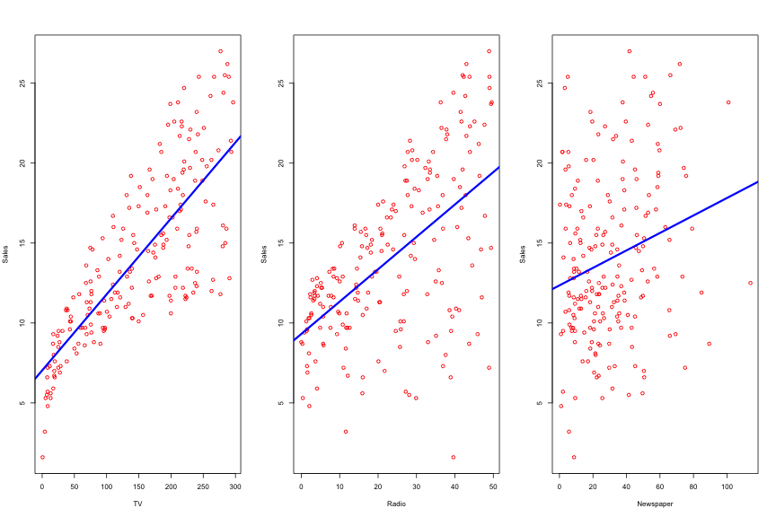

======================================================== # 分析單位

- 個人：所有成人、65 歲以上成人、孕婦等等
- 群體：學校的班級、醫院的單位
- 個人有可能受到群體的影響；個人的差異有可能同時來自群體以及個人本身
- 有分析單位才能確定測量的方式。例如：個人的身高、體重、生活品質必須以個人為單位進行測量。一個國家的醫療品質、生育率、離婚率等等則是以國家為單位測量。

======================================================== # 測量

- 抽象概念例如「生活品質」、「顧客滿意度」需要轉換成可測量的概念，測量之後得到變數。
- 例如：「顧客滿意度」就是對於品質以及付出價格相比在心理上的滿意程度。
- 一個概念如果有不止一個面向，可以考慮用一個以上的測量。
- 例如：「心理健康」測量包括自己的生理狀況評估、與家人、朋友相處情況等等。
- 例如：「休閒運動」測量包括去過幾次美術館、每週做幾次明顯的流汗運動等等。

[figure not shown]